# Challenge B R

Maylis Dauxois, Camille Quideau

08/12/2017

## TASK 1B

# Step 1

ML technique choosen : Random Forest. What is it ?

Random Forest is a machine learning (an algorithm), for classification and regression. In this library, there are many classes, which represent many « trees » in this « forest ». We can extract trees from the « forest » to regress our model (here we want to predict house prices in Ames, so we want to regress the price according to many different variables).

For this : we can add, substract, combine, … trees to an ensemble, to see if a class is significant or not in our regression or predictionN. In fact : we can make a prediction of test data using random forest, that is what we want to do : Predicting house prices in Ames. The prediction will depend on which class we add or substract from our model.

# Step 2 : For this step, we will make a linear regression of the training data, using random Forest.

```r
library(tidyverse)
library(randomForest)
library(readr)
```

We import Dataset from CSV an choose « train.csv »

```r
set.seed(1)
train <- read_csv("~/rprog/Challenge A /data/raw-data/train.csv")
train
```

```
## # A tibble: 1,460 x 81
##       Id MSSubClass MSZoning LotFrontage LotArea Street Alley LotShape
##    <int>      <int>    <chr>       <int>   <int>  <chr> <chr>    <chr>
##  1     1         60       RL          65    8450   Pave  <NA>      Reg
##  2     2         20       RL          80    9600   Pave  <NA>      Reg
##  3     3         60       RL          68   11250   Pave  <NA>      IR1
##  4     4         70       RL          60    9550   Pave  <NA>      IR1
##  5     5         60       RL          84   14260   Pave  <NA>      IR1
##  6     6         50       RL          85   14115   Pave  <NA>      IR1
##  7     7         20       RL          75   10084   Pave  <NA>      Reg
##  8     8         60       RL          NA   10382   Pave  <NA>      IR1
##  9     9         50       RM          51    6120   Pave  <NA>      Reg
## 10    10        190       RL          50    7420   Pave  <NA>      Reg
## # ... with 1,450 more rows, and 73 more variables: LandContour <chr>,
## #   Utilities <chr>, LotConfig <chr>, LandSlope <chr>, Neighborhood <chr>,
## #   Condition1 <chr>, Condition2 <chr>, BldgType <chr>, HouseStyle <chr>,
## #   OverallQual <int>, OverallCond <int>, YearBuilt <int>,
## #   YearRemodAdd <int>, RoofStyle <chr>, RoofMatl <chr>,
## #   Exterior1st <chr>, Exterior2nd <chr>, MasVnrType <chr>,
## #   MasVnrArea <int>, ExterQual <chr>, ExterCond <chr>, Foundation <chr>,
## #   BsmtQual <chr>, BsmtCond <chr>, BsmtExposure <chr>,
## #   BsmtFinType1 <chr>, BsmtFinSF1 <int>, BsmtFinType2 <chr>,
## #   BsmtFinSF2 <int>, BsmtUnfSF <int>, TotalBsmtSF <int>, Heating <chr>,
## #   HeatingQC <chr>, CentralAir <chr>, Electrical <chr>, `1stFlrSF` <int>,
## #   `2ndFlrSF` <int>, LowQualFinSF <int>, GrLivArea <int>,
## #   BsmtFullBath <int>, BsmtHalfBath <int>, FullBath <int>,
## #   HalfBath <int>, BedroomAbvGr <int>, KitchenAbvGr <int>,
## #   KitchenQual <chr>, TotRmsAbvGrd <int>, Functional <chr>,
## #   Fireplaces <int>, FireplaceQu <chr>, GarageType <chr>,
## #   GarageYrBlt <int>, GarageFinish <chr>, GarageCars <int>,
## #   GarageArea <int>, GarageQual <chr>, GarageCond <chr>,
## #   PavedDrive <chr>, WoodDeckSF <int>, OpenPorchSF <int>,
## #   EnclosedPorch <int>, `3SsnPorch` <int>, ScreenPorch <int>,
## #   PoolArea <int>, PoolQC <chr>, Fence <chr>, MiscFeature <chr>,
## #   MiscVal <int>, MoSold <int>, YrSold <int>, SaleType <chr>,
## #   SaleCondition <chr>, SalePrice <int>
```

We can have a look on the dataset, running the command and change all character as factors.

```r
dim(train)
```

```
## [1] 1460   81
```

```r
colnames(train)
```

```
##  [1] "Id"            "MSSubClass"    "MSZoning"      "LotFrontage"
##  [5] "LotArea"       "Street"        "Alley"         "LotShape"
##  [9] "LandContour"   "Utilities"     "LotConfig"     "LandSlope"
## [13] "Neighborhood"  "Condition1"    "Condition2"    "BldgType"
## [17] "HouseStyle"    "OverallQual"   "OverallCond"   "YearBuilt"
## [21] "YearRemodAdd"  "RoofStyle"     "RoofMatl"      "Exterior1st"
## [25] "Exterior2nd"   "MasVnrType"    "MasVnrArea"    "ExterQual"
## [29] "ExterCond"     "Foundation"    "BsmtQual"      "BsmtCond"
## [33] "BsmtExposure"  "BsmtFinType1"  "BsmtFinSF1"    "BsmtFinType2"
## [37] "BsmtFinSF2"    "BsmtUnfSF"     "TotalBsmtSF"   "Heating"
## [41] "HeatingQC"     "CentralAir"    "Electrical"    "1stFlrSF"
## [45] "2ndFlrSF"      "LowQualFinSF"  "GrLivArea"     "BsmtFullBath"
## [49] "BsmtHalfBath"  "FullBath"      "HalfBath"      "BedroomAbvGr"
## [53] "KitchenAbvGr"  "KitchenQual"   "TotRmsAbvGrd"  "Functional"
## [57] "Fireplaces"    "FireplaceQu"   "GarageType"    "GarageYrBlt"
## [61] "GarageFinish"  "GarageCars"    "GarageArea"    "GarageQual"
## [65] "GarageCond"    "PavedDrive"    "WoodDeckSF"    "OpenPorchSF"
## [69] "EnclosedPorch" "3SsnPorch"     "ScreenPorch"   "PoolArea"
## [73] "PoolQC"        "Fence"         "MiscFeature"   "MiscVal"
## [77] "MoSold"        "YrSold"        "SaleType"      "SaleCondition"
## [81] "SalePrice"
```

```r
sapply(train,class)
```

```
##            Id    MSSubClass      MSZoning   LotFrontage       LotArea
##     "integer"     "integer"   "character"     "integer"     "integer"
##        Street         Alley      LotShape   LandContour     Utilities
##   "character"   "character"   "character"   "character"   "character"
##     LotConfig     LandSlope  Neighborhood    Condition1    Condition2
##   "character"   "character"   "character"   "character"   "character"
##      BldgType    HouseStyle   OverallQual   OverallCond     YearBuilt
##   "character"   "character"     "integer"     "integer"     "integer"
##  YearRemodAdd     RoofStyle      RoofMatl   Exterior1st   Exterior2nd
##     "integer"   "character"   "character"   "character"   "character"
##    MasVnrType    MasVnrArea     ExterQual     ExterCond    Foundation
##   "character"     "integer"   "character"   "character"   "character"
##      BsmtQual      BsmtCond  BsmtExposure  BsmtFinType1    BsmtFinSF1
##   "character"   "character"   "character"   "character"     "integer"
##  BsmtFinType2    BsmtFinSF2     BsmtUnfSF   TotalBsmtSF       Heating
##   "character"     "integer"     "integer"     "integer"   "character"
##     HeatingQC    CentralAir    Electrical      1stFlrSF      2ndFlrSF
##   "character"   "character"   "character"     "integer"     "integer"
##  LowQualFinSF     GrLivArea  BsmtFullBath  BsmtHalfBath      FullBath
##     "integer"     "integer"     "integer"     "integer"     "integer"
##      HalfBath  BedroomAbvGr  KitchenAbvGr   KitchenQual  TotRmsAbvGrd
##     "integer"     "integer"     "integer"   "character"     "integer"
##    Functional    Fireplaces   FireplaceQu    GarageType   GarageYrBlt
##   "character"     "integer"   "character"   "character"     "integer"
##  GarageFinish    GarageCars    GarageArea    GarageQual    GarageCond
##   "character"     "integer"     "integer"   "character"   "character"
##    PavedDrive    WoodDeckSF   OpenPorchSF EnclosedPorch     3SsnPorch
##   "character"     "integer"     "integer"     "integer"     "integer"
##   ScreenPorch      PoolArea        PoolQC         Fence   MiscFeature
##     "integer"     "integer"   "character"   "character"   "character"
##       MiscVal        MoSold        YrSold      SaleType SaleCondition
##     "integer"     "integer"     "integer"   "character"   "character"
##     SalePrice
##     "integer"
```

```r
head(train)
```

```
## # A tibble: 6 x 81
##      Id MSSubClass MSZoning LotFrontage LotArea Street Alley LotShape
##   <int>      <int>    <chr>       <int>   <int>  <chr> <chr>    <chr>
## 1     1         60       RL          65    8450   Pave  <NA>      Reg
## 2     2         20       RL          80    9600   Pave  <NA>      Reg
## 3     3         60       RL          68   11250   Pave  <NA>      IR1
## 4     4         70       RL          60    9550   Pave  <NA>      IR1
## 5     5         60       RL          84   14260   Pave  <NA>      IR1
## 6     6         50       RL          85   14115   Pave  <NA>      IR1
## # ... with 73 more variables: LandContour <chr>, Utilities <chr>,
## #   LotConfig <chr>, LandSlope <chr>, Neighborhood <chr>,
## #   Condition1 <chr>, Condition2 <chr>, BldgType <chr>, HouseStyle <chr>,
## #   OverallQual <int>, OverallCond <int>, YearBuilt <int>,
## #   YearRemodAdd <int>, RoofStyle <chr>, RoofMatl <chr>,
## #   Exterior1st <chr>, Exterior2nd <chr>, MasVnrType <chr>,
## #   MasVnrArea <int>, ExterQual <chr>, ExterCond <chr>, Foundation <chr>,
## #   BsmtQual <chr>, BsmtCond <chr>, BsmtExposure <chr>,
## #   BsmtFinType1 <chr>, BsmtFinSF1 <int>, BsmtFinType2 <chr>,
## #   BsmtFinSF2 <int>, BsmtUnfSF <int>, TotalBsmtSF <int>, Heating <chr>,
## #   HeatingQC <chr>, CentralAir <chr>, Electrical <chr>, `1stFlrSF` <int>,
## #   `2ndFlrSF` <int>, LowQualFinSF <int>, GrLivArea <int>,
## #   BsmtFullBath <int>, BsmtHalfBath <int>, FullBath <int>,
## #   HalfBath <int>, BedroomAbvGr <int>, KitchenAbvGr <int>,
## #   KitchenQual <chr>, TotRmsAbvGrd <int>, Functional <chr>,
## #   Fireplaces <int>, FireplaceQu <chr>, GarageType <chr>,
## #   GarageYrBlt <int>, GarageFinish <chr>, GarageCars <int>,
## #   GarageArea <int>, GarageQual <chr>, GarageCond <chr>,
## #   PavedDrive <chr>, WoodDeckSF <int>, OpenPorchSF <int>,
## #   EnclosedPorch <int>, `3SsnPorch` <int>, ScreenPorch <int>,
## #   PoolArea <int>, PoolQC <chr>, Fence <chr>, MiscFeature <chr>,
## #   MiscVal <int>, MoSold <int>, YrSold <int>, SaleType <chr>,
## #   SaleCondition <chr>, SalePrice <int>
```

```r
train[sapply(train,is.character)]<-lapply(train[sapply(train,is.character)], as.factor)
```

We substract all missing values (NA) using summarise and filter functions

```r
remove.vars <- train %>% summarise_all(.funs = funs(sum(is.na(.)))) %>% gather(key = "feature", value = "missing.observations") %>% filter(missing.observations > 100) %>% select(feature) %>% unlist
train <- train %>% select(-one_of(remove.vars))
train %>% summarise_all(.funs = funs(sum(is.na(.)))) %>% gather(key = "feature", value = "missing.observations") %>% filter(missing.observations > 0)
```

```
## # A tibble: 13 x 2
##         feature missing.observations
##           <chr>                <int>
##  1   MasVnrType                    8
##  2   MasVnrArea                    8
##  3     BsmtQual                   37
##  4     BsmtCond                   37
##  5 BsmtExposure                   38
##  6 BsmtFinType1                   37
##  7 BsmtFinType2                   38
##  8   Electrical                    1
##  9   GarageType                   81
## 10  GarageYrBlt                   81
## 11 GarageFinish                   81
## 12   GarageQual                   81
## 13   GarageCond                   81
```

```r
train <- train %>% filter(is.na(GarageType) == FALSE, is.na(MasVnrType) == FALSE, is.na(BsmtFinType2) == FALSE, is.na(BsmtExposure) == FALSE, is.na(Electrical) == FALSE)
train %>% summarise_all(.funs = funs(sum(is.na(.)))) %>% gather(key = "feature", value = "missing.observations") %>% filter(missing.observations > 0)
```

```
## # A tibble: 0 x 2
## # ... with 2 variables: feature <chr>, missing.observations <int>
```

We, now, have no NA in our dataset.

```r
fit <-randomForest(as.factor(SalePrice) ~ MSZoning+LotArea+Neighborhood+OverallQual+YearBuilt+YearRemodAdd,data=train,importance=TRUE,ntree=10)
```

# Step 3 : We import dataset test and select only important parameters and subset them. Then we will substract all the missing values

```r
library(readr)
test <- read_csv("~/rprog/Challenge A /data/raw-data/test.csv")
test[sapply(test, is.character)] <- lapply(test[sapply(test, is.character)], as.factor)
sapply(test,class)
```

```
##            Id    MSSubClass      MSZoning   LotFrontage       LotArea
##     "integer"     "integer"      "factor"     "integer"     "integer"
##        Street         Alley      LotShape   LandContour     Utilities
##      "factor"      "factor"      "factor"      "factor"      "factor"
##     LotConfig     LandSlope  Neighborhood    Condition1    Condition2
##      "factor"      "factor"      "factor"      "factor"      "factor"
##      BldgType    HouseStyle   OverallQual   OverallCond     YearBuilt
##      "factor"      "factor"     "integer"     "integer"     "integer"
##  YearRemodAdd     RoofStyle      RoofMatl   Exterior1st   Exterior2nd
##     "integer"      "factor"      "factor"      "factor"      "factor"
##    MasVnrType    MasVnrArea     ExterQual     ExterCond    Foundation
##      "factor"     "integer"      "factor"      "factor"      "factor"
##      BsmtQual      BsmtCond  BsmtExposure  BsmtFinType1    BsmtFinSF1
##      "factor"      "factor"      "factor"      "factor"     "integer"
##  BsmtFinType2    BsmtFinSF2     BsmtUnfSF   TotalBsmtSF       Heating
##      "factor"     "integer"     "integer"     "integer"      "factor"
##     HeatingQC    CentralAir    Electrical      1stFlrSF      2ndFlrSF
##      "factor"      "factor"      "factor"     "integer"     "integer"
##  LowQualFinSF     GrLivArea  BsmtFullBath  BsmtHalfBath      FullBath
##     "integer"     "integer"     "integer"     "integer"     "integer"
##      HalfBath  BedroomAbvGr  KitchenAbvGr   KitchenQual  TotRmsAbvGrd
##     "integer"     "integer"     "integer"      "factor"     "integer"
##    Functional    Fireplaces   FireplaceQu    GarageType   GarageYrBlt
##      "factor"     "integer"      "factor"      "factor"     "integer"
##  GarageFinish    GarageCars    GarageArea    GarageQual    GarageCond
##      "factor"     "integer"     "integer"      "factor"      "factor"
##    PavedDrive    WoodDeckSF   OpenPorchSF EnclosedPorch     3SsnPorch
##      "factor"     "integer"     "integer"     "integer"     "integer"
##   ScreenPorch      PoolArea        PoolQC         Fence   MiscFeature
##     "integer"     "integer"      "factor"      "factor"      "factor"
##       MiscVal        MoSold        YrSold      SaleType SaleCondition
##     "integer"     "integer"     "integer"      "factor"      "factor"
```

```r
test[sapply(test,is.character)]<-lapply(test[sapply(test,is.character)], as.factor)
```

```r
remove.vars <- test %>% summarise_all(.funs = funs(sum(is.na(.)))) %>% gather(key = "feature", value = "missing.observations") %>% filter(missing.observations > 100) %>% select(feature) %>% unlist
test <- test %>% select(-one_of(remove.vars))
test %>% summarise_all(.funs = funs(sum(is.na(.)))) %>% gather(key = "feature", value = "missing.observations") %>% filter(missing.observations > 0)
```

```
## # A tibble: 27 x 2
##         feature missing.observations
##           <chr>                <int>
##  1     MSZoning                    4
##  2    Utilities                    2
##  3  Exterior1st                    1
##  4  Exterior2nd                    1
##  5   MasVnrType                   16
##  6   MasVnrArea                   15
##  7     BsmtQual                   44
##  8     BsmtCond                   45
##  9 BsmtExposure                   44
## 10 BsmtFinType1                   42
## # ... with 17 more rows
```

```r
test <- test %>% filter(is.na(GarageType) == FALSE, is.na(MasVnrType) == FALSE, is.na(BsmtFinType2) == FALSE, is.na(BsmtExposure) == FALSE, is.na(Electrical) == FALSE)
test %>% summarise_all(.funs = funs(sum(is.na(.)))) %>% gather(key = "feature", value = "missing.observations") %>% filter(missing.observations > 0)
```

```
## # A tibble: 13 x 2
##         feature missing.observations
##           <chr>                <int>
##  1     MSZoning                    1
##  2    Utilities                    1
##  3     BsmtQual                    2
##  4     BsmtCond                    3
##  5  KitchenQual                    1
##  6   Functional                    1
##  7  GarageYrBlt                    2
##  8 GarageFinish                    2
##  9   GarageCars                    1
## 10   GarageArea                    1
## 11   GarageQual                    2
## 12   GarageCond                    2
## 13     SaleType                    1
```

```r
model<-lm(SalePrice~MSZoning+LotArea+Neighborhood+OverallQual+YearBuilt+YearRemodAdd,data=train, na.action (na.omit (train)))
```

Make prediction of the model created using model (linear regression)

```r
prediction <- data.frame(Id = test$Id, SalePrice_predict = predict(model, test, type="response"))
summary(prediction)
```

```
##        Id       SalePrice_predict
##  Min.   :1461   Min.   : 11938
##  1st Qu.:1818   1st Qu.:133424
##  Median :2184   Median :170637
##  Mean   :2186   Mean   :184108
##  3rd Qu.:2546   3rd Qu.:216345
##  Max.   :2919   Max.   :393118
##                 NA's   :1
```

For the linear regression, we obtain the min, median, max, …

Prediction of a linear regression using random forest

```r
Prediction2 <- (predict(fit, test, type="response"))
summary(Prediction2)
```

```
##  135000  190000  143000  155000  130000  140000  160000  110000  156000
##      24      23      19      16      15      15      15      14      14
##  250000  119500  176000  180000  185000  187500  230000  139000  173000
##      14      13      13      13      13      13      13      12      12
##  181000  119000  147000   91000  115000  125000  144000  148500  166000
##      12      11      11      10      10      10      10      10      10
##  196000  318000  127000  175000  113000  117000  132000  145000  157000
##      10      10       9       9       8       8       8       8       8
##  235000  328900  100000  118500  124000  129000  152000  158000  168000
##       8       8       7       7       7       7       7       7       7
##  177000  210000  260000  274000  120500  132500  142000  151000  169990
##       7       7       7       7       6       6       6       6       6
##  170000  196500  240000  270000  275000  335000   79000  120000  125500
##       6       6       6       6       6       6       5       5       5
##  129900  130500  131500  134450  141500  161000  174000  189000  200141
##       5       5       5       5       5       5       5       5       5
##  202500  207500  215000  220000  232000  276000  310000  328000  345000
##       5       5       5       5       5       5       5       5       5
##  380000   85000   87000   89471  105000  109500  112000  119900  122000
##       5       4       4       4       4       4       4       4       4
##  123000  131000  143500  148800  150000  165000  178000  179200 (Other)
##       4       4       4       4       4       4       4       4     554
##    NA's
##       1
```

## With the ML technique of random forests we have categorical values, for example 4 houses have a price of 165 000 dollars, whereas with the linear regression we have continuous values with a price mean of houses in Ames, Iowa of 184 100 dollars.

## Task 2B

We copy the code we used in Task 2A in challenge A.

# Step 1 - Estimate a low-flexibility local linear model on the training data. For that, you can use function npreg the package np. Choose ll for the method (local linear), and a bandwidth of 0.5; Call this model ll.fit.lowflex

```r
library(np)
ll.fit.lowflex <- npreg (y ~ x, bws = 0.5, data = training, regtype = "ll")
summary(ll.fit.lowflex)
```

```
##
## Regression Data: 122 training points, in 1 variable(s)
##                 x
## Bandwidth(s): 0.5
##
## Kernel Regression Estimator: Local-Linear
## Bandwidth Type: Fixed
## Residual standard error: 1.085438
## R-squared: 0.8540956
##
## Continuous Kernel Type: Second-Order Gaussian
## No. Continuous Explanatory Vars.: 1
```

# Step 2 - Estimate a high-flexibility local linear model on the training data. For that, you can use function npreg the package np. Choose ll for the method (local linear), and a bandwidth of 0.01; Call this model ll.fit.highflex

```r
ll.fit.highflex <- npreg (y ~ x, bws = 0.01, data = training, regtype = "ll")
summary(ll.fit.highflex)
```

```
##
## Regression Data: 122 training points, in 1 variable(s)
##                  x
## Bandwidth(s): 0.01
##
## Kernel Regression Estimator: Local-Linear
## Bandwidth Type: Fixed
## Residual standard error: 0.5070779
## R-squared: 0.9680171
##
## Continuous Kernel Type: Second-Order Gaussian
## No. Continuous Explanatory Vars.: 1
```

# Step 3 - Plot the scatterplot of x-y, along with the predictions of ll.fit.lowflex and ll.fit.highflex, on only the training data. See Figure 1.

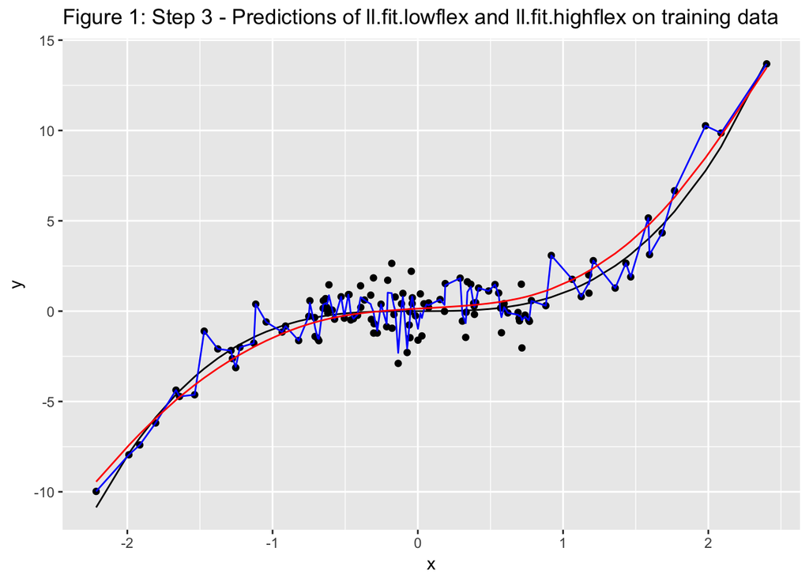

```r
training <- training %>% mutate(y.ll = predict(object = ll.fit.highflex))
training <- training %>% mutate(y.lll = predict(object = ll.fit.lowflex))
ggplot(training) + ggtitle("Figure 1: Step 3 - Predictions of ll.fit.lowflex and ll.fit.highflex on training data") + geom_point(mapping = aes(x = x, y = y)) +
  geom_line(mapping = aes(x = x, y = y.true)) +
  geom_line(mapping = aes(x = x, y = y.ll), color = "blue") +
  geom_line(mapping = aes(x = x, y = y.lll), color = "red")
```

# Step 4 - Between the two models, which predictions are more variable? Which predictions have the least bias?

```r
summary (training)
```

```
##        y                 x                y.true
##  Min.   :-9.9764   Min.   :-2.21470   Min.   :-10.862872
##  1st Qu.:-0.8527   1st Qu.:-0.60640   1st Qu.: -0.223158
##  Median : 0.1640   Median :-0.05772   Median : -0.000193
##  Mean   : 0.1258   Mean   :-0.02833   Mean   :  0.023239
##  3rd Qu.: 0.9759   3rd Qu.: 0.56646   3rd Qu.:  0.181814
##  Max.   :13.6876   Max.   : 2.40162   Max.   : 13.851974
##   which.data             y.lm               y.ll             y.lll
##  Length:122         Min.   :-5.21898   Min.   :-9.9764   Min.   :-9.4419
##  Class :character   1st Qu.:-1.28735   1st Qu.:-0.5022   1st Qu.:-0.4112
##  Mode  :character   Median : 0.05394   Median : 0.2195   Median : 0.1105
##                     Mean   : 0.12579   Mean   : 0.1333   Mean   : 0.1296
##                     3rd Qu.: 1.57980   3rd Qu.: 0.8026   3rd Qu.: 0.5125
##                     Max.   : 6.06601   Max.   :13.6876   Max.   :13.4805
```

The predictions of the high flexibility linear model are the more variable ones, the predictions with this model have the least bias because the difference between the scatterpoints and the regression are minimized by the bigger variation of the regression.

# Step 5 - Plot the scatterplot of x-y, along with the predictions of ll.fit.lowflex and ll.fit.highflex now using the test data. Which predictions are more variable? What happened to the bias of the least biased model?

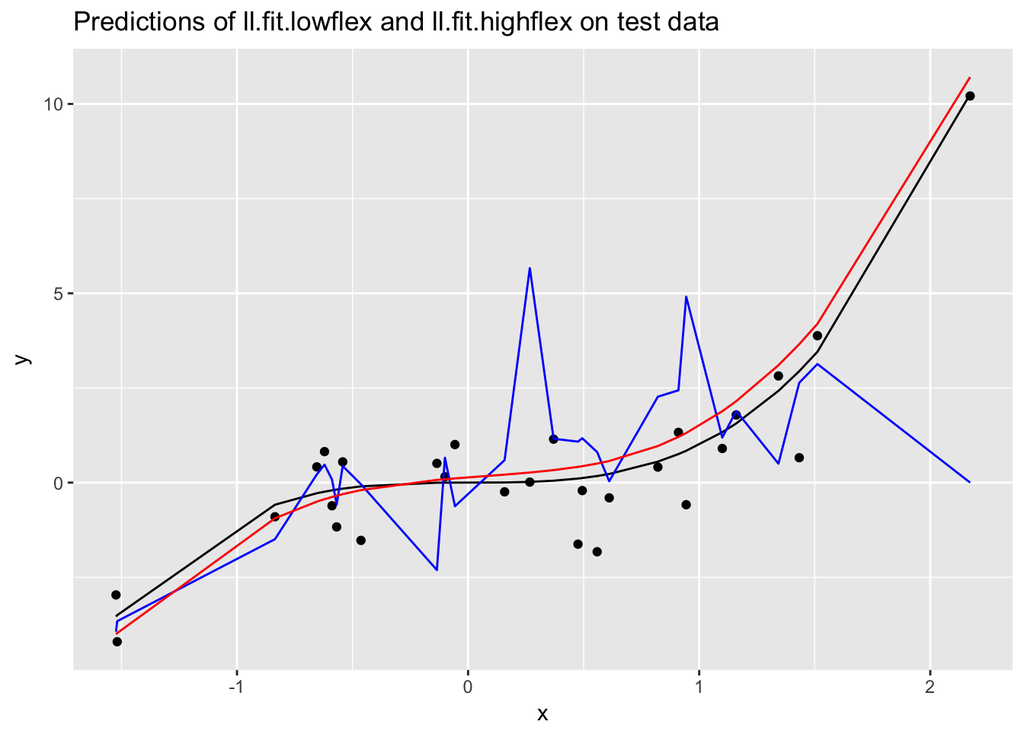

```r
test <- test %>% mutate(y.ll.lowflex = predict(object = ll.fit.lowflex, newdata = test), y.ll.highflex = predict(object = ll.fit.highflex, newdata = test))

ggplot(test) + geom_point(mapping = aes(x = x, y = y)) +
  geom_line(mapping = aes(x = x, y = y.true))+
  geom_line(data=test, aes(x=x, y=y.ll.highflex), col="blue")+
  geom_line(data=test, aes(x=x, y=y.ll.lowflex), col="red")+
  ggtitle("Predictions of ll.fit.lowflex and ll.fit.highflex on test data")
```

```r
summary(test)
```

```
##        y                 x               y.true          which.data
##  Min.   :-4.2019   Min.   :-1.5236   Min.   :-3.53659   Length:28
##  1st Qu.:-0.6842   1st Qu.:-0.5491   1st Qu.:-0.16573   Class :character
##  Median : 0.2822   Median : 0.3186   Median : 0.03486   Mode  :character
##  Mean   : 0.3689   Mean   : 0.2400   Mean   : 0.57249
##  3rd Qu.: 0.9269   3rd Qu.: 0.9186   3rd Qu.: 0.77570
##  Max.   :10.2105   Max.   : 2.1726   Max.   :10.25525
##   y.ll.lowflex     y.ll.highflex
##  Min.   :-4.0055   Min.   :-3.93749
##  1st Qu.:-0.3157   1st Qu.:-0.01088
##  Median : 0.2984   Median : 0.54722
##  Mean   : 0.7531   Mean   : 0.66774
##  3rd Qu.: 1.2318   3rd Qu.: 1.36518
##  Max.   :10.7108   Max.   : 5.66190
```

# Step 6 - Create a vector of bandwidth going from 0.01 to 0.5 with a step of 0.001

```r
bdw <- seq(0.01, 0.5, by = 0.001)
```

# Step 7 - Estimate a local linear model y ~ x on the training data with each bandwidth.

```r
ll.fit.flex <- lapply(X = bdw, FUN = function(bdw) {npreg(y~x, data =training, method = "ll", bws = bdw)})
```

# Step 8 - Compute for each bandwidth the MSE on the training data.

```r
mse.training <- function(fit.model){
  predictions <- predict(object = fit.model, newdata = training)
  training %>% mutate(squared.error = (y - predictions)^2) %>% summarize(mse = mean(squared.error))
}
mse.training.results <- unlist(lapply(X = ll.fit.flex, FUN = mse.training))
mse.training.results
```

```
##       mse       mse       mse       mse       mse       mse       mse
## 0.3460818 0.3708529 0.3947976 0.4181274 0.4408973 0.4630605 0.4845110
##       mse       mse       mse       mse       mse       mse       mse
## 0.5051165 0.5247438 0.5432788 0.5606400 0.5767855 0.5917133 0.6054576
##       mse       mse       mse       mse       mse       mse       mse
## 0.6180814 0.6296688 0.6403162 0.6501252 0.6591967 0.6676263 0.6755010
##       mse       mse       mse       mse       mse       mse       mse
## 0.6828973 0.6898806 0.6965051 0.7028144 0.7088429 0.7146168 0.7201557
##       mse       mse       mse       mse       mse       mse       mse
## 0.7254743 0.7305835 0.7354915 0.7402053 0.7447307 0.7490737 0.7532403
##       mse       mse       mse       mse       mse       mse       mse
## 0.7572372 0.7610717 0.7647515 0.7682851 0.7716815 0.7749502 0.7781005
##       mse       mse       mse       mse       mse       mse       mse
## 0.7811423 0.7840851 0.7869382 0.7897108 0.7924116 0.7950487 0.7976296
##       mse       mse       mse       mse       mse       mse       mse
## 0.8001614 0.8026504 0.8051023 0.8075222 0.8099143 0.8122826 0.8146301
##       mse       mse       mse       mse       mse       mse       mse
## 0.8169595 0.8192729 0.8215720 0.8238580 0.8261316 0.8283935 0.8306439
##       mse       mse       mse       mse       mse       mse       mse
## 0.8328828 0.8351100 0.8373250 0.8395275 0.8417169 0.8438925 0.8460537
##       mse       mse       mse       mse       mse       mse       mse
## 0.8481998 0.8503301 0.8524439 0.8545407 0.8566197 0.8586806 0.8607228
##       mse       mse       mse       mse       mse       mse       mse
## 0.8627459 0.8647496 0.8667335 0.8686975 0.8706414 0.8725650 0.8744685
##       mse       mse       mse       mse       mse       mse       mse
## 0.8763517 0.8782147 0.8800578 0.8818809 0.8836845 0.8854686 0.8872337
##       mse       mse       mse       mse       mse       mse       mse
## 0.8889799 0.8907078 0.8924176 0.8941097 0.8957845 0.8974425 0.8990842
##       mse       mse       mse       mse       mse       mse       mse
## 0.9007099 0.9023202 0.9039155 0.9054964 0.9070632 0.9086165 0.9101567
##       mse       mse       mse       mse       mse       mse       mse
## 0.9116844 0.9132001 0.9147042 0.9161972 0.9176797 0.9191520 0.9206147
##       mse       mse       mse       mse       mse       mse       mse
## 0.9220683 0.9235132 0.9249498 0.9263787 0.9278003 0.9292150 0.9306233
##       mse       mse       mse       mse       mse       mse       mse
## 0.9320256 0.9334223 0.9348138 0.9362006 0.9375830 0.9389615 0.9403364
##       mse       mse       mse       mse       mse       mse       mse
## 0.9417081 0.9430770 0.9444435 0.9458079 0.9471705 0.9485317 0.9498918
##       mse       mse       mse       mse       mse       mse       mse
## 0.9512512 0.9526101 0.9539690 0.9553280 0.9566875 0.9580477 0.9594090
```

[output cut: 87 more lines]

```
## 1.8271723 1.8320500 1.8369410 1.8418452 1.8467626 1.8516932 1.8566369
##       mse       mse       mse       mse       mse       mse       mse
## 1.8615937 1.8665636 1.8715465 1.8765424 1.8815513 1.8865730 1.8916076
##       mse       mse       mse       mse       mse       mse       mse
## 1.8966550 1.9017152 1.9067881 1.9118737 1.9169720 1.9220828 1.9272062
##       mse       mse       mse       mse       mse       mse       mse
## 1.9323421 1.9374905 1.9426513 1.9478244 1.9530099 1.9582076 1.9634175
##       mse       mse       mse       mse       mse       mse       mse
## 1.9686396 1.9738738 1.9791201 1.9843783 1.9896486 1.9949307 2.0002247
##       mse       mse       mse       mse       mse       mse       mse
## 2.0055305 2.0108480 2.0161772 2.0215181 2.0268705 2.0322344 2.0376098
##       mse       mse       mse       mse       mse       mse       mse
## 2.0429966 2.0483948 2.0538042 2.0592248 2.0646566 2.0700996 2.0755535
##       mse
## 2.0810184
```

# Step 9 - Compute for each bandwidth the MSE on the test data.

```r
mse.test <- function(fit.model){
  predictions <- predict(object = fit.model, newdata = test)
  test %>% mutate(squared.error = (y - predictions)^2) %>% summarize(mse = mean(squared.error))
}
mse.test.results <- unlist(lapply(X = ll.fit.flex, FUN = mse.test))
mse.test.results
```

```
##       mse       mse       mse       mse       mse       mse       mse
## 2.2572777 2.1896544 2.1268625 2.0712311 2.0233086 1.9825734 1.9479119
##       mse       mse       mse       mse       mse       mse       mse
## 1.9179465 1.8912759 1.8666454 1.8430483 1.8197638 1.7963463 1.7725812
##       mse       mse       mse       mse       mse       mse       mse
## 1.7484269 1.7239552 1.6993005 1.6746216 1.6500777 1.6258149 1.6019605
##       mse       mse       mse       mse       mse       mse       mse
## 1.5786220 1.5558877 1.5338281 1.5124969 1.4919324 1.4721584 1.4531854
##       mse       mse       mse       mse       mse       mse       mse
## 1.4350123 1.4176272 1.4010100 1.3851336 1.3699656 1.3554702 1.3416094
##       mse       mse       mse       mse       mse       mse       mse
## 1.3283442 1.3156358 1.3034460 1.2917383 1.2804780 1.2696325 1.2591717
##       mse       mse       mse       mse       mse       mse       mse
## 1.2490679 1.2392959 1.2298327 1.2206578 1.2117529 1.2031017 1.1946898
##       mse       mse       mse       mse       mse       mse       mse
## 1.1865047 1.1785353 1.1707721 1.1632069 1.1558325 1.1486430 1.1416332
##       mse       mse       mse       mse       mse       mse       mse
## 1.1347987 1.1281357 1.1216412 1.1153124 1.1091469 1.1031426 1.0972977
##       mse       mse       mse       mse       mse       mse       mse
## 1.0916105 1.0860792 1.0807022 1.0754779 1.0704045 1.0654803 1.0607033
##       mse       mse       mse       mse       mse       mse       mse
## 1.0560715 1.0515827 1.0472346 1.0430247 1.0389505 1.0350091 1.0311978
##       mse       mse       mse       mse       mse       mse       mse
## 1.0275134 1.0239529 1.0205132 1.0171908 1.0139825 1.0108849 1.0078945
##       mse       mse       mse       mse       mse       mse       mse
## 1.0050079 1.0022217 0.9995323 0.9969363 0.9944303 0.9920110 0.9896750
##       mse       mse       mse       mse       mse       mse       mse
## 0.9874190 0.9852399 0.9831345 0.9810997 0.9791326 0.9772302 0.9753897
##       mse       mse       mse       mse       mse       mse       mse
## 0.9736085 0.9718838 0.9702131 0.9685939 0.9670239 0.9655008 0.9640223
##       mse       mse       mse       mse       mse       mse       mse
## 0.9625864 0.9611911 0.9598343 0.9585143 0.9572292 0.9559773 0.9547571
##       mse       mse       mse       mse       mse       mse       mse
## 0.9535670 0.9524055 0.9512711 0.9501626 0.9490786 0.9480180 0.9469795
##       mse       mse       mse       mse       mse       mse       mse
## 0.9459622 0.9449648 0.9439866 0.9430264 0.9420835 0.9411569 0.9402459
##       mse       mse       mse       mse       mse       mse       mse
## 0.9393498 0.9384678 0.9375993 0.9367436 0.9359001 0.9350683 0.9342477
##       mse       mse       mse       mse       mse       mse       mse
## 0.9334378 0.9326381 0.9318482 0.9310677 0.9302962 0.9295334 0.9287790
```

[output cut: 87 more lines]

```
## 1.2805165 1.2838806 1.2872568 1.2906450 1.2940453 1.2974575 1.3008817
##       mse       mse       mse       mse       mse       mse       mse
## 1.3043178 1.3077658 1.3112257 1.3146973 1.3181808 1.3216759 1.3251827
##       mse       mse       mse       mse       mse       mse       mse
## 1.3287012 1.3322313 1.3357730 1.3393262 1.3428908 1.3464670 1.3500545
##       mse       mse       mse       mse       mse       mse       mse
## 1.3536534 1.3572636 1.3608851 1.3645179 1.3681618 1.3718169 1.3754832
##       mse       mse       mse       mse       mse       mse       mse
## 1.3791604 1.3828487 1.3865480 1.3902583 1.3939794 1.3977114 1.4014541
##       mse       mse       mse       mse       mse       mse       mse
## 1.4052077 1.4089719 1.4127468 1.4165323 1.4203284 1.4241350 1.4279521
##       mse       mse       mse       mse       mse       mse       mse
## 1.4317796 1.4356175 1.4394657 1.4433242 1.4471930 1.4510719 1.4549609
##       mse
## 1.4588600
```

# Step 10 - Draw on the same plot how the MSE on training data, and test data, change when the bandwidth increases. Conclude.

```r
mse.df <- tbl_df(data.frame(bandwidth = bdw, mse.train = mse.training.results, mse.test = mse.test.results))
mse.df
```

```
## # A tibble: 491 x 3
##    bandwidth mse.train mse.test
##        <dbl>     <dbl>    <dbl>
##  1     0.010 0.3460818 2.257278
##  2     0.011 0.3708529 2.189654
##  3     0.012 0.3947976 2.126863
##  4     0.013 0.4181274 2.071231
##  5     0.014 0.4408973 2.023309
##  6     0.015 0.4630605 1.982573
##  7     0.016 0.4845110 1.947912
##  8     0.017 0.5051165 1.917947
##  9     0.018 0.5247438 1.891276
## 10     0.019 0.5432788 1.866645
## # ... with 481 more rows
```

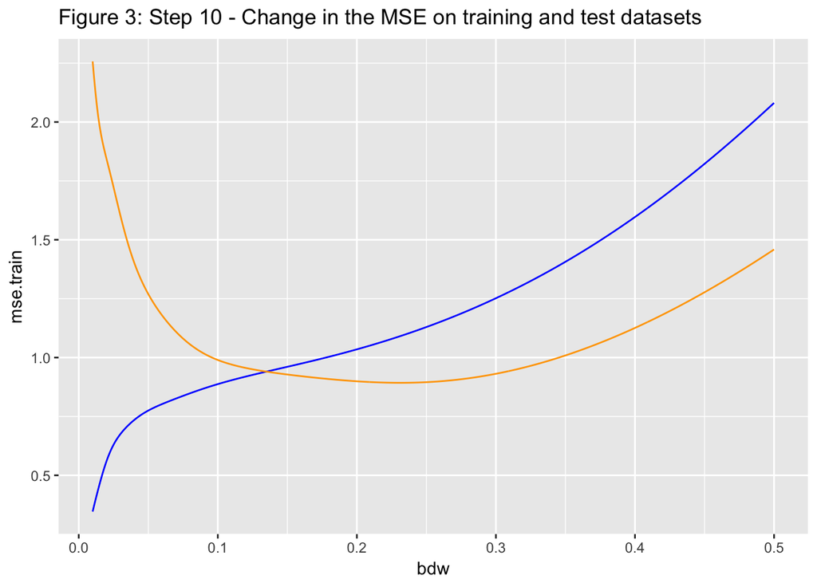

```r
ggplot(mse.df) + ggtitle("Figure 3: Step 10 - Change in the MSE on training and test datasets") +
  geom_line(mapping = aes(x = bdw, y = mse.train), color = "blue") +
  geom_line(mapping = aes(x = bdw, y = mse.test), color = "orange")
```